# Lesson 4: Introduction to Tidyverse

Ashir Borah and Natalie Elphick

October 29th, 2024

Press the “?” key for tips on navigating these slides

## Recap (key concepts so far)

- Variables, data types and data structures in R
- Functions (using, getting help, making your own)
- Loading and saving data
- Using Rstudio, Projects, and Markdown notebooks
- Working with data in vectors, lists, matrices, and dataframes (tables)

# Tidyverse

## Tidyverse

- The tidyverse packages work well together because they share common data representations and design principles
  - Rows = Observations/Samples
  - Columns = Variables/Measurements
- [ggplot2](https://ggplot2.tidyverse.org/), for data visualization.
- [dplyr](https://dplyr.tidyverse.org/), for data manipulation.
- [tidyr](https://tidyr.tidyverse.org/), for data tidying.
- [readr](https://readr.tidyverse.org/), for data import.
- [purrr](https://purrr.tidyverse.org/), for iteration.
- and more..

# Data Wrangling

## Data Wrangling

- Turning messy data into useful statistics and visualizations
- Taking some datasets (the ‘nouns’) and applying a series of transformations (the ‘verbs’)
- These transformations are nessecary to create the format needed to create outputs (plots, summary tables etc.)

## Pipes

We often want to apply multiple functions (‘verbs’) to our data in a chain.

[figure not shown]

`%>%` is a special R symbol for chaining together functions (part of `tidyverse`)

## Pipe Example

```r
# Hard to read
bop(scoop(hop(foo_foo, through = forest), up = field_mice), on = head)

# Creating unnecessary 'temporary' variables
foo_foo_1 <- hop(foo_foo, through = forest)
foo_foo_2 <- scoop(foo_foo_1, up = field_mice)
foo_foo_3 <- bop(foo_foo_2, on = head)
```

Using pipes makes your code easy to read and understand as a series of verbs

```r
foo_foo %>%
  hop(through = forest) %>%
  scoop(up = field_mice) %>%
  bop(on = head)
```

## Pipe Example

Assigning the results of a chain to a new variable

```r
result <- input_data %>% function_1 %>% function_2
```

The pipe feeds the *first* argument of the next function

```r
x <- c('a', 'b', 'c')
x %>% c('d')
```

```
[1] "a" "b" "c" "d"
```

If you want the piped input to feed a different argument, you can use `.`:

```r
x %>% c('d', .)
```

```
[1] "d" "a" "b" "c"
```

## Why use pipes

- Code is easier to read (and modify)
- This style of coding is less prone to errors due to misplaced parentheses associated with nested function calls
- Using pipes is a choice! Use it when it’s helpful
- Note: Rstudio keyboard shortcut: Cmd + shift + M

## Base R Pipe

- Introduced in R 4.1.0, the base R pipe is represented by `|>`
- It works similarly to %>%

```r
x <- c('a', 'b', 'c')
x |> c('d')
```

```
[1] "a" "b" "c" "d"
```

Use `_` as a placeholder if the pipe output should go to a different argument:

```r
x |> rep(x = _, 2)
```

```
[1] "a" "b" "c" "a" "b" "c"
```

When using the placeholder `_` the arguement must be named.

# Data wrangling verbs

## dplyr

- Offers a set of verbs for data manipulation
  - [mutate()](https://dplyr.tidyverse.org/reference/mutate.html) adds new variables that are functions of existing columns
  - [select()](https://dplyr.tidyverse.org/reference/select.html) picks columns based on their names
  - [filter()](https://dplyr.tidyverse.org/reference/filter.html) picks rows based on their values
  - [summarise()](https://dplyr.tidyverse.org/reference/summarise.html) reduces multiple values down to a single summary
  - [arrange()](https://dplyr.tidyverse.org/reference/arrange.html) changes the ordering of the rows
  - [group_by()](https://dplyr.tidyverse.org/reference/group_by.html) allows any function above to be applied within a categorical grouping

## Gapminder package

```r
#install.packages('gapminder')
library(gapminder)
```

```r
head(gapminder)
```

```
# A tibble: 6 × 6
  country     continent  year lifeExp      pop gdpPercap
  <fct>       <fct>     <int>   <dbl>    <int>     <dbl>
1 Afghanistan Asia       1952    28.8  8425333      779.
2 Afghanistan Asia       1957    30.3  9240934      821.
3 Afghanistan Asia       1962    32.0 10267083      853.
4 Afghanistan Asia       1967    34.0 11537966      836.
5 Afghanistan Asia       1972    36.1 13079460      740.
6 Afghanistan Asia       1977    38.4 14880372      786.
```

## Filter

- Select a subset of the rows from a tibble
- Arguments are the ‘filters’ you’d like to apply

```r
gapminder %>% filter(year == 2007)
```

```
# A tibble: 142 × 6
   country     continent  year lifeExp       pop gdpPercap
   <fct>       <fct>     <int>   <dbl>     <int>     <dbl>
 1 Afghanistan Asia       2007    43.8  31889923      975.
 2 Albania     Europe     2007    76.4   3600523     5937.
 3 Algeria     Africa     2007    72.3  33333216     6223.
 4 Angola      Africa     2007    42.7  12420476     4797.
 5 Argentina   Americas   2007    75.3  40301927    12779.
 6 Australia   Oceania    2007    81.2  20434176    34435.
 7 Austria     Europe     2007    79.8   8199783    36126.
 8 Bahrain     Asia       2007    75.6    708573    29796.
 9 Bangladesh  Asia       2007    64.1 150448339     1391.
10 Belgium     Europe     2007    79.4  10392226    33693.
# ℹ 132 more rows
```

- Use `==` to pick rows with variable equal to a specified value.

## Logical operators for filtering

- Use `,` to check for multiple filters being true (‘AND’)

```r
gapminder %>%
  filter(year == 2002, continent == "Asia") %>%
  sample_n(4)
```

```
# A tibble: 4 × 6
  country          continent  year lifeExp      pop gdpPercap
  <fct>            <fct>     <int>   <dbl>    <int>     <dbl>
1 Oman             Asia       2002    74.2  2713462    19775.
2 Kuwait           Asia       2002    76.9  2111561    35110.
3 Korea, Dem. Rep. Asia       2002    66.7 22215365     1647.
4 Philippines      Asia       2002    70.3 82995088     2651.
```

## Logical operators for filtering

- Use `|` to check for any in multiple filters being true (‘OR’)

```r
gapminder %>%
  filter(year == 2002 | continent == "Asia") %>%
  sample_n(4)
```

```
# A tibble: 4 × 6
  country   continent  year lifeExp      pop gdpPercap
  <fct>     <fct>     <int>   <dbl>    <int>     <dbl>
1 Jordan    Asia       1952    43.2   607914     1547.
2 Bahrain   Asia       1957    53.8   138655    11636.
3 Australia Oceania    2002    80.4 19546792    30688.
4 Nepal     Asia       1972    44.0 12412593      675.
```

## Logical operators for filtering

- Use `%in%` to check if value is contained in a specified set

```r
gapminder %>%
  filter(country %in% c("Argentina", "Belgium", "Mexico"),
         year %in% c(1987, 1992))
```

```
# A tibble: 6 × 6
  country   continent  year lifeExp      pop gdpPercap
  <fct>     <fct>     <int>   <dbl>    <int>     <dbl>
1 Argentina Americas   1987    70.8 31620918     9140.
2 Argentina Americas   1992    71.9 33958947     9308.
3 Belgium   Europe     1987    75.4  9870200    22526.
4 Belgium   Europe     1992    76.5 10045622    25576.
5 Mexico    Americas   1987    69.5 80122492     8688.
6 Mexico    Americas   1992    71.5 88111030     9472.
```

## select

- Use `select` to pick a subset of columns by name

```r
gapminder %>%
  select(country, year, lifeExp) %>%
  head(4)
```

```
# A tibble: 4 × 3
  country      year lifeExp
  <fct>       <int>   <dbl>
1 Afghanistan  1952    28.8
2 Afghanistan  1957    30.3
3 Afghanistan  1962    32.0
4 Afghanistan  1967    34.0
```

## Handling Columns with Non-standard Names

- Select columns with non-standard names
  - Starts with number, special character or contains spaces
- Use back-ticks (**not** single quotes), tab complete column names will do this for you

```r
df %>% select(`1999`, `variable with spaces`)
```

## rename

- Use `rename` to rename certain columns
  - Expected format: new name = old name

```r
gapminder %>%
  rename(lifeExpectancy = lifeExp, population = pop) %>%
  head(3)
```

```
# A tibble: 3 × 6
  country     continent  year lifeExpectancy population gdpPercap
  <fct>       <fct>     <int>          <dbl>      <int>     <dbl>
1 Afghanistan Asia       1952           28.8    8425333      779.
2 Afghanistan Asia       1957           30.3    9240934      821.
3 Afghanistan Asia       1962           32.0   10267083      853.
```

- Note that any column names you don’t include are left unchanged

## arrange

- Reorder rows based on the values of one or more variables

```r
gapminder %>%
  arrange(year) %>%
  head(4)
```

```
# A tibble: 4 × 6
  country     continent  year lifeExp     pop gdpPercap
  <fct>       <fct>     <int>   <dbl>   <int>     <dbl>
1 Afghanistan Asia       1952    28.8 8425333      779.
2 Albania     Europe     1952    55.2 1282697     1601.
3 Algeria     Africa     1952    43.1 9279525     2449.
4 Angola      Africa     1952    30.0 4232095     3521.
```

## arrange

- Sorting by multiple variables

```r
gapminder %>%
  arrange(year, lifeExp) %>%
  head(4)
```

```
# A tibble: 4 × 6
  country      continent  year lifeExp     pop gdpPercap
  <fct>        <fct>     <int>   <dbl>   <int>     <dbl>
1 Afghanistan  Asia       1952    28.8 8425333      779.
2 Gambia       Africa     1952    30    284320      485.
3 Angola       Africa     1952    30.0 4232095     3521.
4 Sierra Leone Africa     1952    30.3 2143249      880.
```

## desc

- Can also sort in descending order

```r
gapminder %>%
  filter(year > 2000) %>%
  arrange(desc(country)) %>%
  head(4)
```

```
# A tibble: 4 × 6
  country  continent  year lifeExp      pop gdpPercap
  <fct>    <fct>     <int>   <dbl>    <int>     <dbl>
1 Zimbabwe Africa     2002    40.0 11926563      672.
2 Zimbabwe Africa     2007    43.5 12311143      470.
3 Zambia   Africa     2002    39.2 10595811     1072.
4 Zambia   Africa     2007    42.4 11746035     1271.
```

## mutate

- **Create a new variable with a specific value**
- Create a new variable that is a function of existing variables
- Overwrite the contents of an existing variable

```r
gapminder %>%
  mutate(just_one = 1) %>%
  head(4)
```

```
# A tibble: 4 × 7
  country     continent  year lifeExp      pop gdpPercap just_one
  <fct>       <fct>     <int>   <dbl>    <int>     <dbl>    <dbl>
1 Afghanistan Asia       1952    28.8  8425333      779.        1
2 Afghanistan Asia       1957    30.3  9240934      821.        1
3 Afghanistan Asia       1962    32.0 10267083      853.        1
4 Afghanistan Asia       1967    34.0 11537966      836.        1
```

## mutate

- Create a new variable with a specific value
- **Create a new variable that is a function of existing variables**
- Overwrite the contents of an existing variable

```r
gapminder %>%
  mutate(gdp = pop * gdpPercap) %>%
  head(4)
```

```
# A tibble: 4 × 7
  country     continent  year lifeExp      pop gdpPercap         gdp
  <fct>       <fct>     <int>   <dbl>    <int>     <dbl>       <dbl>
1 Afghanistan Asia       1952    28.8  8425333      779. 6567086330.
2 Afghanistan Asia       1957    30.3  9240934      821. 7585448670.
3 Afghanistan Asia       1962    32.0 10267083      853. 8758855797.
4 Afghanistan Asia       1967    34.0 11537966      836. 9648014150.
```

## mutate

- Create a new variable with a specific value
- Create a new variable that is a function of existing variables
- **Overwrite the contents of an existing variable**

```r
gapminder %>%
  mutate(pop = pop/1e6) %>%
  head(4)
```

```
# A tibble: 4 × 6
  country     continent  year lifeExp   pop gdpPercap
  <fct>       <fct>     <int>   <dbl> <dbl>     <dbl>
1 Afghanistan Asia       1952    28.8  8.43      779.
2 Afghanistan Asia       1957    30.3  9.24      821.
3 Afghanistan Asia       1962    32.0 10.3       853.
4 Afghanistan Asia       1967    34.0 11.5       836.
```

## mutate and ifelse

```r
x <- 10
ifelse(x > 9, "x is greater than 9", "x is not greater than 9")
```

```
[1] "x is greater than 9"
```

Allows you to use mutate in a ‘condition-dependent’ way

```r
gapminder %>%
  mutate(adjusted_gdp = ifelse(year < 1980, gdpPercap * 2, gdpPercap)) %>%
  sample_n(5)
```

```
# A tibble: 5 × 7
  country  continent  year lifeExp      pop gdpPercap adjusted_gdp
  <fct>    <fct>     <int>   <dbl>    <int>     <dbl>        <dbl>
1 Rwanda   Africa     1952    40    2534927      493.         987.
2 Zimbabwe Africa     1957    50.5  3646340      519.        1038.
3 Uganda   Africa     1972    51.0 10190285      951.        1901.
4 Reunion  Africa     1982    69.9   517810     5267.        5267.
5 Cuba     Americas   1997    76.2 10983007     5432.        5432.
```

## summarise

- Apply a numerical summary to a column of a table

```r
gapminder %>%
  filter(year == 1997) %>%
  summarise(max_exp = max(lifeExp),
            sd_exp = sd(lifeExp))
```

```
# A tibble: 1 × 2
  max_exp sd_exp
    <dbl>  <dbl>
1    80.7   11.6
```

- Works with any functions that take a vector as input and return a single value

## group_by

- Combined with `summarise`, `group_by` allows you to summarise data for each possible value of a categorical variable

```r
gapminder %>%
  filter(year == 1997) %>%
  group_by(continent) %>%
  summarise(max_exp = max(lifeExp),
            sd_exp = sd(lifeExp))
```

```
# A tibble: 5 × 3
  continent max_exp sd_exp
  <fct>       <dbl>  <dbl>
1 Africa       74.8  9.10
2 Americas     78.6  4.89
3 Asia         80.7  8.09
4 Europe       79.4  3.10
5 Oceania      78.8  0.905
```

## group_by

- Can be applied to combinations of variables

```r
gapminder %>%
  group_by(continent, year) %>%
  summarise(num_rows = n(),
            max_exp = max(lifeExp),
            sd_exp = sd(lifeExp)) %>%
  head(4)
```

```
# A tibble: 4 × 5
# Groups:   continent [1]
  continent  year num_rows max_exp sd_exp
  <fct>     <int>    <int>   <dbl>  <dbl>
1 Africa     1952       52    52.7   5.15
2 Africa     1957       52    58.1   5.62
3 Africa     1962       52    60.2   5.88
4 Africa     1967       52    61.6   6.08
```

- `n()` function counts number of rows in each group

# Recap

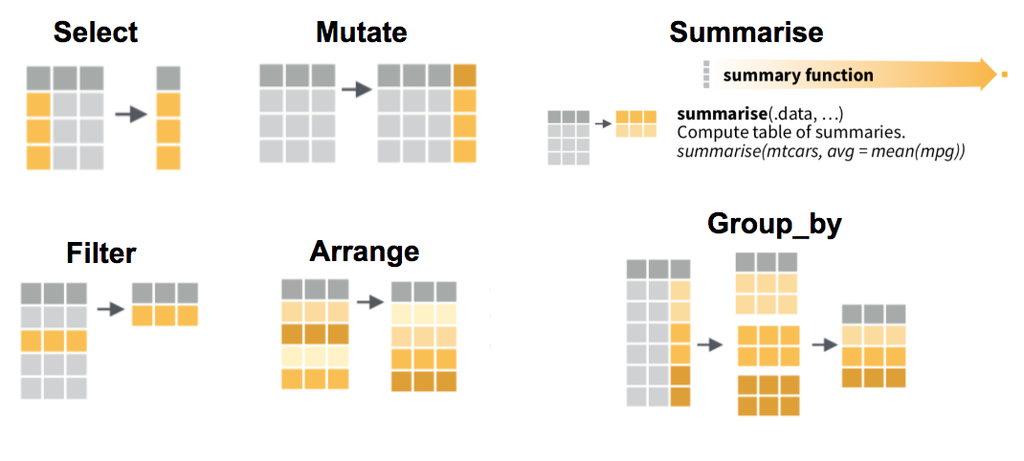

[dplyr cheat sheet](https://posit.co/wp-content/uploads/2022/10/data-transformation-1.pdf)

## Additional resources

- [dplyr intro](https://dplyr.tidyverse.org/articles/dplyr.html)
- More on pipes: [DataCamp](https://www.datacamp.com/community/tutorials/pipe-r-tutorial), [TowardsDataScience](https://towardsdatascience.com/an-introduction-to-the-pipe-in-r-823090760d64)

# ChatGPT/LLMs Tips for R

## General Tips

- Follow [UCSF’s institutional guidelines](https://ai.ucsf.edu/ucsf-ai-guidance) on using LLMs
- Always **critically review** the outputs of LLMs
- Provide **as much detail as possible** about the problem in the 1st prompt
- Use separate chats for separate tasks/projects
- Commented R code yields better responses
- Never input sensitive data into an LLM

## When to use LLMs?

- To help you understand coding concepts by providing examples and explanations
- To reformat or optimize code that already works
- To explain what someone else’s code is doing
- To write **small** amounts of code that you can test easily

Over-reliance on LLMs to write your code can prevent you from learning the basics.

## Coding with LLMs Tips

- LLMs have a limited context (memory)
  - If you query them long enough they “forget”
- Provide short blocks of code (fewer than 200 lines)
- Works best on single functions instead of whole code files
- Include in the 1st prompt the kinds of code outputs you want
  - “Output short blocks of commented code”
  - “Output only the code you modified”
  - “Make minimal changes to fix the issue”

## Prompt Engineering

- Developing and optimizing prompts to get the desired outputs from LLMs
- **Zero-shot**: the prompt does not contain examples
- **Few-shot**: the prompt contains a few examples of responses
- **Chain-of-thought**: Few-shot but the examples explain their reasoning

This is an on-going field of active research, see this [guide](https://www.promptingguide.ai/techniques) for more techniques.

## Recap

- Avoid over-reliance on LLMs
- Provide lots of details about the problem in the 1st prompt
- If the outputs do not make sense then try different styles of prompting